# ASavoskin_solutions

## Курсовой проект по курсу "Библиотеки Python для Data Science: продолжение"

**Задача**

Требуется, на основании имеющихся данных о клиентах банка, построить модель, используя обучающий датасет, для прогнозирования невыполнения долговых обязательств по текущему кредиту. Выполнить прогноз для примеров из тестового датасета.

**Наименование файлов с данными**

course_project_train.csv - обучающий датасет  
course_project_test.csv - тестовый датасет

**Целевая переменная**

Credit Default - факт невыполнения кредитных обязательств

**Метрика качества**

F1-score (sklearn.metrics.f1_score)

**Требования к решению**

*Целевая метрика*

- F1 > 0.5
- Метрика оценивается по качеству прогноза для главного класса (1 - просрочка по кредиту)

**Описание датасета**

- **Home Ownership** - домовладение
- **Annual Income** - годовой доход
- **Years in current job** - количество лет на текущем месте работы
- **Tax Liens** - налоговые обременения
- **Number of Open Accounts** - количество открытых счетов
- **Years of Credit History** - количество лет кредитной истории
- **Maximum Open Credit** - наибольший открытый кредит
- **Number of Credit Problems** - количество проблем с кредитом
- **Months since last delinquent** - количество месяцев с последней просрочки платежа
- **Bankruptcies** - банкротства
- **Purpose** - цель кредита
- **Term** - срок кредита
- **Current Loan Amount** - текущая сумма кредита
- **Current Credit Balance** - текущий кредитный баланс
- **Monthly Debt** - ежемесячный долг
- **Credit Score** - баллы кредитного рейтинга
- **Credit Default** - факт невыполнения кредитных обязательств (0 - погашен вовремя, 1 - просрочка)

Импорт библиотек:

```python
import numpy as np
import pandas as pd
import matplotlib.pyplot as plt
import seaborn as sns
import scipy.stats as stats

from sklearn.model_selection import train_test_split, learning_curve
from sklearn.metrics import classification_report, f1_score, precision_score, recall_score
from sklearn.model_selection import StratifiedKFold, GridSearchCV, RandomizedSearchCV
from sklearn.ensemble import RandomForestClassifier

import statsmodels.api as sm
from statsmodels.formula.api import ols

%matplotlib inline
```

Загружаем данные:

```python
TRAIN_DATASET_PATH = './data1/course_project_train.csv'
TEST_DATASET_PATH = './data1/course_project_test.csv'
```

```python
df_train = pd.read_csv(TRAIN_DATASET_PATH)
df_test = pd.read_csv(TEST_DATASET_PATH)
```

Добавим функции, для анализа работы классификатора:

```python
# сравнение работы модели на тренировочной и валидационной выборках
def evaluate_preds(model, X_train, X_test, y_train, y_test):
    y_train_pred = model.predict(X_train)
    y_test_pred = model.predict(X_test)
    def get_classification_report(y_train_true, y_train_pred, y_test_true, y_test_pred):
        print('TRAIN\n\n' + classification_report(y_train_true, y_train_pred))
        print('TEST\n\n' + classification_report(y_test_true, y_test_pred))
        print('CONFUSION MATRIX\n')
        print(pd.crosstab(y_test_true, y_test_pred))
    get_classification_report(y_train, y_train_pred, y_test, y_test_pred)
```

```python
# просмотр значимых признаков для модели
def show_feature_importances(feature_names, feature_importances, get_top=None):
    feature_importances = pd.DataFrame({'feature': feature_names, 'importance': feature_importances})
    if get_top is not None:
        feature_importances=feature_importances.sort_values('importance', ascending=False)[:get_top]
    else:
        feature_importances = feature_importances.sort_values('importance', ascending=False)


    plt.figure(figsize = (20, len(feature_importances) * 0.355))

    sns.barplot(x='importance', y='feature', data=feature_importances)

    plt.xlabel('Importance')
    plt.title('Importance of features')
    plt.show()

    #if get_top is not None:
    #    return feature_importances['feature'][:get_top].tolist()
```

```python
def show_proba_calibration_plots(y_predicted_probs, y_true_labels):
    preds_with_true_labels = np.array(list(zip(y_predicted_probs, y_true_labels)))

    thresholds = []
    precisions = []
    recalls = []
    f1_scores = []

    for threshold in np.linspace(0.1, 0.9, 9):
        thresholds.append(threshold)
        precisions.append(precision_score(y_true_labels, list(map(int, y_predicted_probs > threshold)), zero_division=1))
        recalls.append(recall_score(y_true_labels, list(map(int, y_predicted_probs > threshold))))
        f1_scores.append(f1_score(y_true_labels, list(map(int, y_predicted_probs > threshold))))

    scores_table = pd.DataFrame({'f1':f1_scores,
                                 'precision':precisions,
                                 'recall':recalls,
                                 'probability':thresholds}).sort_values('f1', ascending=False).round(3)

    figure = plt.figure(figsize = (15, 5))

    plt1 = figure.add_subplot(121)
    plt1.plot(thresholds, precisions, label='Precision', linewidth=4)
    plt1.plot(thresholds, recalls, label='Recall', linewidth=4)
    plt1.plot(thresholds, f1_scores, label='F1', linewidth=4)
    plt1.set_ylabel('Scores')
    plt1.set_xlabel('Probability threshold')
    plt1.set_title('Probabilities threshold calibration')
    plt1.legend(bbox_to_anchor=(0.25, 0.25))
    plt1.table(cellText = scores_table.values,
               colLabels = scores_table.columns,
               colLoc = 'center', cellLoc = 'center', loc = 'bottom', bbox = [0, -1.3, 1, 1])

    plt2 = figure.add_subplot(122)
    plt2.hist(preds_with_true_labels[preds_with_true_labels[:, 1] == 0][:, 0],
              label='Another class', color='royalblue', alpha=1)
    plt2.hist(preds_with_true_labels[preds_with_true_labels[:, 1] == 1][:, 0],
              label='Main class', color='darkcyan', alpha=0.8)
    plt2.set_ylabel('Number of examples')
    plt2.set_xlabel('Probabilities')
    plt2.set_title('Probability histogram')
    plt2.legend(bbox_to_anchor=(1, 1))

    plt.show()
```

```python
def show_learning_curve_plot(estimator, X, y, cv=5, n_jobs=-1, train_sizes=np.linspace(.1, 1.0, 5)):

    #Determines cross-validated training and test scores for different training set sizes.
    train_sizes, train_scores, test_scores = learning_curve(estimator, X, y,
                                                            cv=cv,
                                                            scoring='f1',
                                                            train_sizes=train_sizes,
                                                            n_jobs=n_jobs)
    train_scores_mean = np.mean(train_scores, axis=1)
    train_scores_std = np.std(train_scores, axis=1)
    test_scores_mean = np.mean(test_scores, axis=1)
    test_scores_std = np.std(test_scores, axis=1)

    plt.figure(figsize=(15,8))
    plt.fill_between(train_sizes, train_scores_mean - train_scores_std,
                     train_scores_mean + train_scores_std, alpha=0.1, color="r")
    plt.fill_between(train_sizes, test_scores_mean - test_scores_std,
                     test_scores_mean + test_scores_std, alpha=0.1, color="g")
    plt.plot(train_sizes, train_scores_mean, 'o-', color="r",
             label="Training score")
    plt.plot(train_sizes, test_scores_mean, 'o-', color="g",
             label="Cross-validation score")

    plt.title(f"Learning curves ({type(estimator).__name__})")
    plt.xlabel("Training examples")
    plt.ylabel("Score")
    plt.legend(loc="best")
    plt.grid()
    plt.show()
```

Посмотрим на датасет:

```python
df_train.head()
```

|  | Home Ownership | Annual Income | Years in current job | Tax Liens | Number of Open Accounts | Years of Credit History | Maximum Open Credit | Number of Credit Problems | Months since last delinquent | Bankruptcies | Purpose | Term | Current Loan Amount | Current Credit Balance | Monthly Debt | Credit Score | Credit Default |
| --- | --- | --- | --- | --- | --- | --- | --- | --- | --- | --- | --- | --- | --- | --- | --- | --- | --- |
| 0 | Own Home | 482087.0 | NaN | 0.0 | 11.0 | 26.3 | 685960.0 | 1.0 | NaN | 1.0 | debt consolidation | Short Term | 99999999.0 | 47386.0 | 7914.0 | 749.0 | 0 |
| 1 | Own Home | 1025487.0 | 10+ years | 0.0 | 15.0 | 15.3 | 1181730.0 | 0.0 | NaN | 0.0 | debt consolidation | Long Term | 264968.0 | 394972.0 | 18373.0 | 737.0 | 1 |
| 2 | Home Mortgage | 751412.0 | 8 years | 0.0 | 11.0 | 35.0 | 1182434.0 | 0.0 | NaN | 0.0 | debt consolidation | Short Term | 99999999.0 | 308389.0 | 13651.0 | 742.0 | 0 |
| 3 | Own Home | 805068.0 | 6 years | 0.0 | 8.0 | 22.5 | 147400.0 | 1.0 | NaN | 1.0 | debt consolidation | Short Term | 121396.0 | 95855.0 | 11338.0 | 694.0 | 0 |
| 4 | Rent | 776264.0 | 8 years | 0.0 | 13.0 | 13.6 | 385836.0 | 1.0 | NaN | 0.0 | debt consolidation | Short Term | 125840.0 | 93309.0 | 7180.0 | 719.0 | 0 |

```python
df_train.describe()
```

|  | Annual Income | Tax Liens | Number of Open Accounts | Years of Credit History | Maximum Open Credit | Number of Credit Problems | Months since last delinquent | Bankruptcies | Current Loan Amount | Current Credit Balance | Monthly Debt | Credit Score | Credit Default |
| --- | --- | --- | --- | --- | --- | --- | --- | --- | --- | --- | --- | --- | --- |
| count | 5.943000e+03 | 7500.000000 | 7500.000000 | 7500.000000 | 7.500000e+03 | 7500.000000 | 3419.000000 | 7486.000000 | 7.500000e+03 | 7.500000e+03 | 7500.000000 | 5943.000000 | 7500.000000 |
| mean | 1.366392e+06 | 0.030133 | 11.130933 | 18.317467 | 9.451537e+05 | 0.170000 | 34.692600 | 0.117152 | 1.187318e+07 | 2.898332e+05 | 18314.454133 | 1151.087498 | 0.281733 |
| std | 8.453392e+05 | 0.271604 | 4.908924 | 7.041946 | 1.602622e+07 | 0.498598 | 21.688806 | 0.347192 | 3.192612e+07 | 3.178714e+05 | 11926.764673 | 1604.451418 | 0.449874 |
| min | 1.645970e+05 | 0.000000 | 2.000000 | 4.000000 | 0.000000e+00 | 0.000000 | 0.000000 | 0.000000 | 1.124200e+04 | 0.000000e+00 | 0.000000 | 585.000000 | 0.000000 |
| 25% | 8.443410e+05 | 0.000000 | 8.000000 | 13.500000 | 2.792295e+05 | 0.000000 | 16.000000 | 0.000000 | 1.801690e+05 | 1.142565e+05 | 10067.500000 | 711.000000 | 0.000000 |
| 50% | 1.168386e+06 | 0.000000 | 10.000000 | 17.000000 | 4.781590e+05 | 0.000000 | 32.000000 | 0.000000 | 3.095730e+05 | 2.093230e+05 | 16076.500000 | 731.000000 | 0.000000 |
| 75% | 1.640137e+06 | 0.000000 | 14.000000 | 21.800000 | 7.935015e+05 | 0.000000 | 50.000000 | 0.000000 | 5.198820e+05 | 3.604062e+05 | 23818.000000 | 743.000000 | 1.000000 |
| max | 1.014934e+07 | 7.000000 | 43.000000 | 57.700000 | 1.304726e+09 | 7.000000 | 118.000000 | 4.000000 | 1.000000e+08 | 6.506797e+06 | 136679.000000 | 7510.000000 | 1.000000 |

```python
# функция просмотра основной информации по датасету:
def show_me_info(df):
    data=df.copy()
    mask=data.isnull()
    missing=mask.sum()
    missing_percent=mask.mean()*100
    data_types=data.dtypes
    unique_values=data.nunique()
    data=pd.concat([data.count(), missing, missing_percent, data_types, unique_values],
                   axis=1,
                   keys=['Total count','Total missing', 'Percent missing', 'Types', 'Unique values']).sort_values(
        by='Total missing', ascending=False)
    return data
```

```python
show_me_info(df_train)
```

|  | Total count | Total missing | Percent missing | Types | Unique values |
| --- | --- | --- | --- | --- | --- |
| Months since last delinquent | 3419 | 4081 | 54.413333 | float64 | 89 |
| Credit Score | 5943 | 1557 | 20.760000 | float64 | 268 |
| Annual Income | 5943 | 1557 | 20.760000 | float64 | 5478 |
| Years in current job | 7129 | 371 | 4.946667 | object | 11 |
| Bankruptcies | 7486 | 14 | 0.186667 | float64 | 5 |
| Purpose | 7500 | 0 | 0.000000 | object | 15 |
| Monthly Debt | 7500 | 0 | 0.000000 | float64 | 6716 |
| Current Credit Balance | 7500 | 0 | 0.000000 | float64 | 6592 |
| Current Loan Amount | 7500 | 0 | 0.000000 | float64 | 5386 |
| Term | 7500 | 0 | 0.000000 | object | 2 |
| Home Ownership | 7500 | 0 | 0.000000 | object | 4 |
| Number of Credit Problems | 7500 | 0 | 0.000000 | float64 | 8 |
| Maximum Open Credit | 7500 | 0 | 0.000000 | float64 | 6963 |
| Years of Credit History | 7500 | 0 | 0.000000 | float64 | 408 |
| Number of Open Accounts | 7500 | 0 | 0.000000 | float64 | 39 |
| Tax Liens | 7500 | 0 | 0.000000 | float64 | 8 |
| Credit Default | 7500 | 0 | 0.000000 | int64 | 2 |

```python
show_me_info(df_test)
```

|  | Total count | Total missing | Percent missing | Types | Unique values |
| --- | --- | --- | --- | --- | --- |
| Months since last delinquent | 1142 | 1358 | 54.32 | float64 | 83 |
| Annual Income | 1987 | 513 | 20.52 | float64 | 1929 |
| Credit Score | 1987 | 513 | 20.52 | float64 | 211 |
| Years in current job | 2414 | 86 | 3.44 | object | 11 |
| Bankruptcies | 2497 | 3 | 0.12 | float64 | 6 |
| Home Ownership | 2500 | 0 | 0.00 | object | 4 |
| Tax Liens | 2500 | 0 | 0.00 | float64 | 8 |
| Number of Open Accounts | 2500 | 0 | 0.00 | float64 | 35 |
| Years of Credit History | 2500 | 0 | 0.00 | float64 | 345 |
| Maximum Open Credit | 2500 | 0 | 0.00 | float64 | 2435 |
| Number of Credit Problems | 2500 | 0 | 0.00 | float64 | 8 |
| Purpose | 2500 | 0 | 0.00 | object | 14 |
| Term | 2500 | 0 | 0.00 | object | 2 |
| Current Loan Amount | 2500 | 0 | 0.00 | float64 | 2026 |
| Current Credit Balance | 2500 | 0 | 0.00 | float64 | 2385 |
| Monthly Debt | 2500 | 0 | 0.00 | float64 | 2416 |

Баланс целевой переменной:

```python
TARGET_VAR='Credit Default'
df_train[TARGET_VAR].value_counts(normalize=True)
```

```
0    0.718267
1    0.281733
Name: Credit Default, dtype: float64
```

Видим, что про количеству пропущенных данных тренировочная и тестовая выборки схожи. Выборка несбалансирована, целевой класс встречается в 2,55 раза реже.

посмотрим на категориальные признаки, сравним их значения на трейне и на тесте:

```python
cat_feature=df_train.select_dtypes(include='object').columns
for name in cat_feature:
    diff=list(set(df_test[name].unique())^set(df_train[name].unique()))
    print(f'Признак: {name: >20}\tРазличия в значениях: {", ".join(diff[i] for i in range(len(diff))) if len(diff)!=0 else "NO": >17}')
```

```
Признак:       Home Ownership	Различия в значениях:                NO
Признак: Years in current job	Различия в значениях:                NO
Признак:              Purpose	Различия в значениях:  renewable energy
Признак:                 Term	Различия в значениях:                NO
```

Посмотрим на распределения признаков, и посмотрим, удастся ли установить взаимосвязь между ними:

```python
NUM_FEATURES=['Annual Income','Maximum Open Credit',  'Current Loan Amount', 'Current Credit Balance', 'Monthly Debt', 'Credit Score']
```

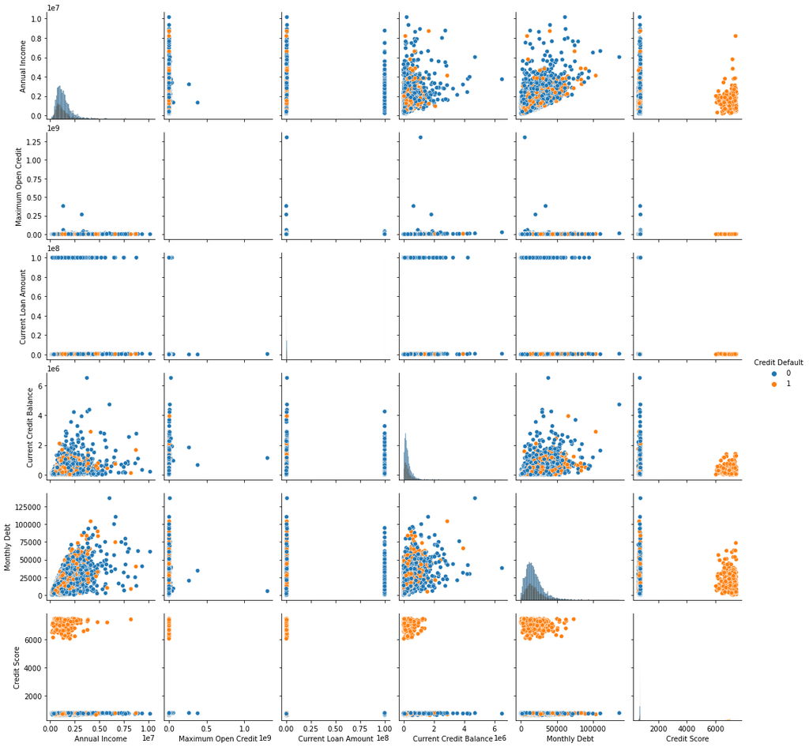

```python
sns.pairplot(df_train[NUM_FEATURES+[TARGET_VAR]], hue=TARGET_VAR, dropna=True, diag_kind='hist')
plt.show()
```

Видим, что значения 'Credit Score' > 6000, и 'Current Loan Amount' >= 99999999.0, хоть и не являются типичными, но явно отделяют часть классов.

Посмотрим на корреляцию признаков

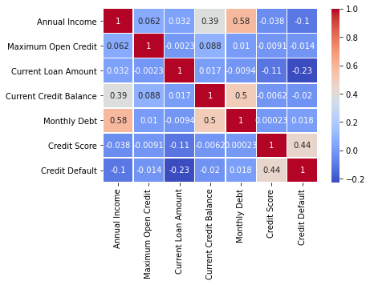

```python
sns.heatmap(df_train[NUM_FEATURES+[TARGET_VAR]].corr(), annot=True, linewidths=.5, cmap='coolwarm')
```

Проанализируем взаимосвязь 'Annual Income'

```python
statmodel=df_train[NUM_FEATURES+[TARGET_VAR]]
columns=statmodel.columns.tolist()
for i in range(len(columns)):
    columns[i]='_'.join(columns[i].split()[j] for j in range(len(columns[i].split())))
statmodel.columns=columns
```

```python
model = ols('Annual_Income~Monthly_Debt',data=statmodel).fit()
model.summary()
```

OLS Regression Results

| Dep. Variable: | Annual_Income | R-squared: | 0.342 |
| --- | --- | --- | --- |
| Model: | OLS | Adj. R-squared: | 0.342 |
| Method: | Least Squares | F-statistic: | 3088. |
| Date: | Thu, 04 Mar 2021 | Prob (F-statistic): | 0.00 |
| Time: | 13:00:04 | Log-Likelihood: | -88296. |
| No. Observations: | 5943 | AIC: | 1.766e+05 |
| Df Residuals: | 5941 | BIC: | 1.766e+05 |
| Df Model: | 1 |  |  |
| Covariance Type: | nonrobust |  |  |

|  | coef | std err | t | P>\|t\| | [0.025 | 0.975] |
| --- | --- | --- | --- | --- | --- | --- |
| Intercept | 6.061e+05 | 1.63e+04 | 37.143 | 0.000 | 5.74e+05 | 6.38e+05 |
| Monthly_Debt | 41.5927 | 0.748 | 55.570 | 0.000 | 40.125 | 43.060 |

| Omnibus: | 4685.087 | Durbin-Watson: | 1.970 |
| --- | --- | --- | --- |
| Prob(Omnibus): | 0.000 | Jarque-Bera (JB): | 148325.936 |
| Skew: | 3.538 | Prob(JB): | 0.00 |
| Kurtosis: | 26.429 | Cond. No. | 4.00e+04 |

Notes:  
[1] Standard Errors assume that the covariance matrix of the errors is correctly specified.  
[2] The condition number is large, 4e+04. This might indicate that there are  
strong multicollinearity or other numerical problems.

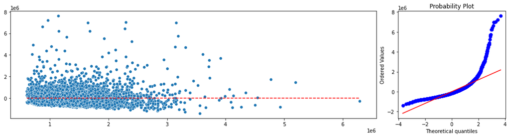

```python
y_pred=model.predict(statmodel)
fig=plt.figure(figsize=(18,4))
gs = fig.add_gridspec(1, 4)
ax1 = fig.add_subplot(gs[0, :-1])
sns.scatterplot(x=y_pred, y=model.resid)
sns.lineplot(x=y_pred, y=0, color='r', linestyle='dashed')
ax2=fig.add_subplot(gs[0, -1])
stats.probplot(model.resid, dist="norm", plot=sns.mpl.pyplot) # y-y_pred=model.resid
plt.show()
```

Так как явно не соблюдается гомоскедастичность остатков и нормальность их распределения-то использовать результаты линейной регрессии для заполнения пропусков в графе 'Annual Income' мы не можем.

Подготовим данные к обработке:

```python
class FeatureImputer1:
    count=0
    def __init__(self):
        self.count+=1


    def fit(self, X, y=None):
        self.dummy_col=['Home Ownership', 'Term', 'Years in current job_ord', 'Purpose_ord']
        self.purpose_change='vacation'
        self.ownership_change='Home Mortgage'
        self.dct={'unknow':0,
                  '< 1 year':1,
                  '1 year':2,
                  '2 years':3,
                  '3 years':4,
                  '4 years':5,
                  '5 years':6,
                  '6 years':7,
                  '7 years':8,
                  '8 years':9,
                  '9 years':10,
                  '10+ years':11}
        self.dct1={'business loan':0,
                   'buy a car':1,
                   'buy house':2,
                   'debt consolidation':3,
                   'educational expenses':4,
                   'home improvements':5,
                   'major purchase':6,
                   'medical bills':7,
                   'moving':8,
                   'other':9,
                   'small business':10,
                   'take a trip':11,
                   'vacation':12,
                   'wedding':13}
        self.drop_col=['Years in current job', 'Purpose']

        self.mean=int(X['Months since last delinquent'].mean())

        return self
    def transform(self, X):
        X_trans=X.copy()
        X_trans.loc[X_trans['Purpose']=='renewable energy', 'Purpose']=self.purpose_change
        X_trans.loc[X_trans['Home Ownership']=='Have Mortgage', 'Home Ownership']=self.ownership_change
        X_trans['Years in current job'].fillna('unknow', inplace=True)
        X_trans.insert(2,'Years in current job_ord',X_trans['Years in current job'].map(self.dct))
        X_trans.insert(X_trans.columns.get_loc('Purpose')+1,'Purpose_ord',X_trans['Purpose'].map(self.dct1))
        X_trans.drop(self.drop_col, axis=1, inplace=True)

        X_trans.loc[(X_trans['Annual Income'].notna())&(X_trans['Months since last delinquent'].isna()), 'Months since last delinquent']=self.mean

        X_trans.fillna(0, inplace=True)
        X_trans=pd.get_dummies(X_trans, columns=self.dummy_col, drop_first=True)

        return X_trans
```

Разделим данные на тренировочную и валидационную выборки

```python
train, val = train_test_split(df_train,
                               test_size=0.2,
                               shuffle=True,
                               stratify=df_train[TARGET_VAR],
                               random_state=12)
```

Подготовим данные:

```python
imputer=FeatureImputer1()
train=imputer.fit(train).transform(train)
val=imputer.transform(val)
```

```python
X_train, y_train, X_val, y_val = train.drop(TARGET_VAR, axis=1), train[TARGET_VAR], val.drop(TARGET_VAR, axis=1), val[TARGET_VAR]
```

В качестве модели используем RandomForestClassifier(), заранее подобранными при помощи GridSearchCV параметрами

```python
%%time
rfc=RandomForestClassifier(max_depth=4, class_weight={0:1,1:2.55}, random_state=100)
rfc.fit(X_train, y_train)
evaluate_preds(rfc, X_train, X_val, y_train, y_val)
```

```
TRAIN

              precision    recall  f1-score   support

           0       0.85      0.73      0.78      4310
           1       0.49      0.67      0.56      1690

    accuracy                           0.71      6000
   macro avg       0.67      0.70      0.67      6000
weighted avg       0.75      0.71      0.72      6000

TEST

              precision    recall  f1-score   support

           0       0.83      0.70      0.76      1077
           1       0.45      0.62      0.52       423

    accuracy                           0.68      1500
   macro avg       0.64      0.66      0.64      1500
weighted avg       0.72      0.68      0.69      1500

CONFUSION MATRIX

col_0             0    1
Credit Default
0               759  318
1               160  263
Wall time: 407 ms
```

Визуализируем дерево решений:

```python
#!pip install pydot
```

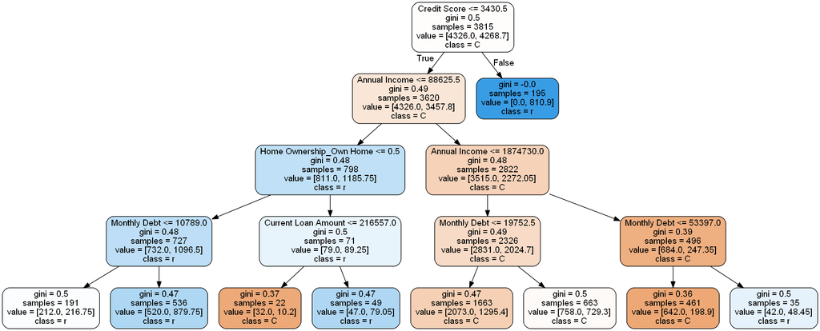

```python
import pydot
from sklearn.tree import export_graphviz
from IPython.display import Image

estimator = rfc.estimators_[5]
export_graphviz(estimator, out_file='./data1/tree.dot',
                feature_names = X_train.columns.tolist(),
                class_names = y_train.name,
                rounded = True, proportion = False,
                precision = 2, filled = True)

(graph,) = pydot.graph_from_dot_file('./data1/tree.dot')
graph.write_png('./data1/tree.png')


from IPython.display import Image
Image(filename = './data1/tree.png')
```

Посмотрим, какие признаки модель сочла самыми важными:

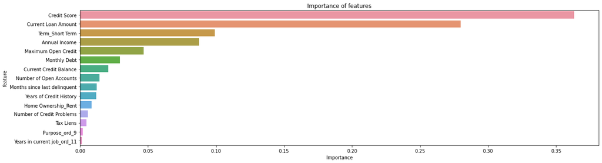

```python
important_features_top = show_feature_importances(X_train.columns,
                                                  rfc.feature_importances_, get_top=15)
```

Кривые обучения:

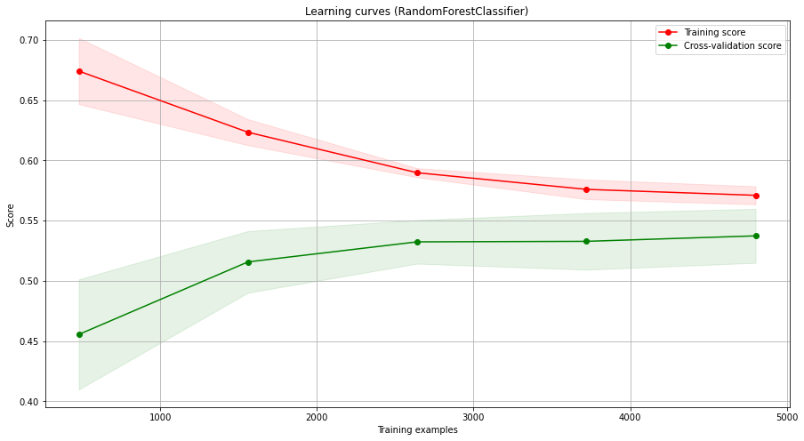

```python
show_learning_curve_plot(rfc, X_train, y_train)
```

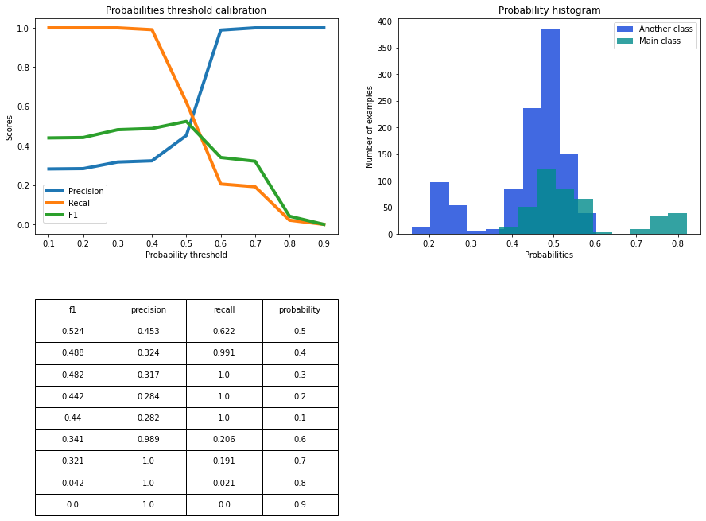

```python
y_val_pred=rfc.predict_proba(X_val)
show_proba_calibration_plots(y_val_pred[:, 1], y_val)
```

Видим, что модель хорошо разделяет данные в диапазоне предсказанных вероятностей <0.37 и >0.6, а между этими значениями модель не может точно разделить классы. Что не удевительно, т.к. данные весьма "грязные".

```python
X_test=imputer.transform(df_test)
y_pred=rfc.predict(X_test)
result=pd.DataFrame({'Id':np.arange(2500), 'Credit Default': y_pred})
```

```python
RESULT_PATH='./data1/ASavoskin_predictions.csv'
result.to_csv(RESULT_PATH, index=False)
```